# Data Exploration

Owen Wurst

Started January 3rd, 2024

The first step of this project is to read in the yahoo finance data and transform it into data that I know how to run ml algorithms on, as well as do some exploratory data analysis and visualization so I have some preliminary knowledge to inspire some model formation.

## Libaries and Imports:

```r
library(tidyverse)
library(gridExtra)
```

```r
library(grid)

source("Data_Prep_Functions.r")
source("Data_Viz_Functions.r")
```

# Reading in Data:

I will start by reading the csv files for all of the data. I will add a column for ticker and industry to each df. Volume does not store actual transaction volume but instead, volume above average %.

```r
# Tech
apple <- read("Original_Datasets/YahooFinance/AAPL.csv")
appl_df <- prep_df_post_csv_read(apple, "APPL", "Tech")

nvidia <- read("Original_Datasets/YahooFinance/NVDA.csv")
nvda_df <- prep_df_post_csv_read(nvidia, "NVDA", "Tech")

meta <- read("Original_Datasets/YahooFinance/META.csv")
meta_df <- prep_df_post_csv_read(meta, "META", "Tech")

# Pharma
jnj <- read("Original_Datasets/YahooFinance/JNJ.csv")
jnj_df <- prep_df_post_csv_read(jnj, "JNJ", "Pharma")

moderna <- read("Original_Datasets/YahooFinance/MRNA.csv")
mrna_df <- prep_df_post_csv_read(moderna, "MRNA", "Pharma")

abbvie <- read("Original_Datasets/YahooFinance/ABBV.csv")
abbv_df <- prep_df_post_csv_read(abbvie, "ABBV", "Pharma")

# Banking
jpmorg <- read("Original_Datasets/YahooFinance/JPM.csv")
jpm_df <- prep_df_post_csv_read(jpmorg, "JPM", "Banking")

mandt <- read("Original_Datasets/YahooFinance/MTB.csv")
mtb_df <- prep_df_post_csv_read(mandt, "MTB", "Banking")

pnc <- read("Original_Datasets/YahooFinance/PNC.csv")
pnc_df <- prep_df_post_csv_read(pnc, "PNC", "Banking")

# Retail
target <- read("Original_Datasets/YahooFinance/TGT.csv")
tgt_df <- prep_df_post_csv_read(target, "TGT", "Retail")

wmt <- read("Original_Datasets/YahooFinance/WMT.csv")
wmt_df <- prep_df_post_csv_read(wmt, "WMT", "Retail")

costco <- read("Original_Datasets/YahooFinance/COST.csv")
cost_df <- prep_df_post_csv_read(costco, "COST", "Retail")

# Add to List
stock_df_list <- list(
  appl_df, nvda_df, meta_df,
  jnj_df, mrna_df, abbv_df,
  jpm_df, mtb_df, pnc_df,
  tgt_df, wmt_df, cost_df
)

combined_df <- do.call(rbind, stock_df_list)
```

After that, we have a list of 12 dataframes that look like this.

```r
head(tgt_df)
```

```
##   Ticker Industry       Date       Volume Adj_Pct_Change Pct_Change
## 1    TGT   Retail 2019-01-01  0.201246946     -0.2639225 12.2041227
## 2    TGT   Retail 2019-02-01  0.004014826    -11.6712821 -0.6292736
## 3    TGT   Retail 2019-03-01  0.171360438     -2.1960091  9.0637401
## 4    TGT   Retail 2019-04-01 -0.011280997    -13.8727873 -3.9573291
## 5    TGT   Retail 2019-05-01  0.498930733     -7.2694984  3.4061618
## 6    TGT   Retail 2019-06-01  0.002133744     -2.7691291  7.4565796
```

# Data Visualization:

I will now take a look at some of the data I have read in to start to visualize some of the trends.

## Stock Price Changes by Industry:

### Tech Stocks:

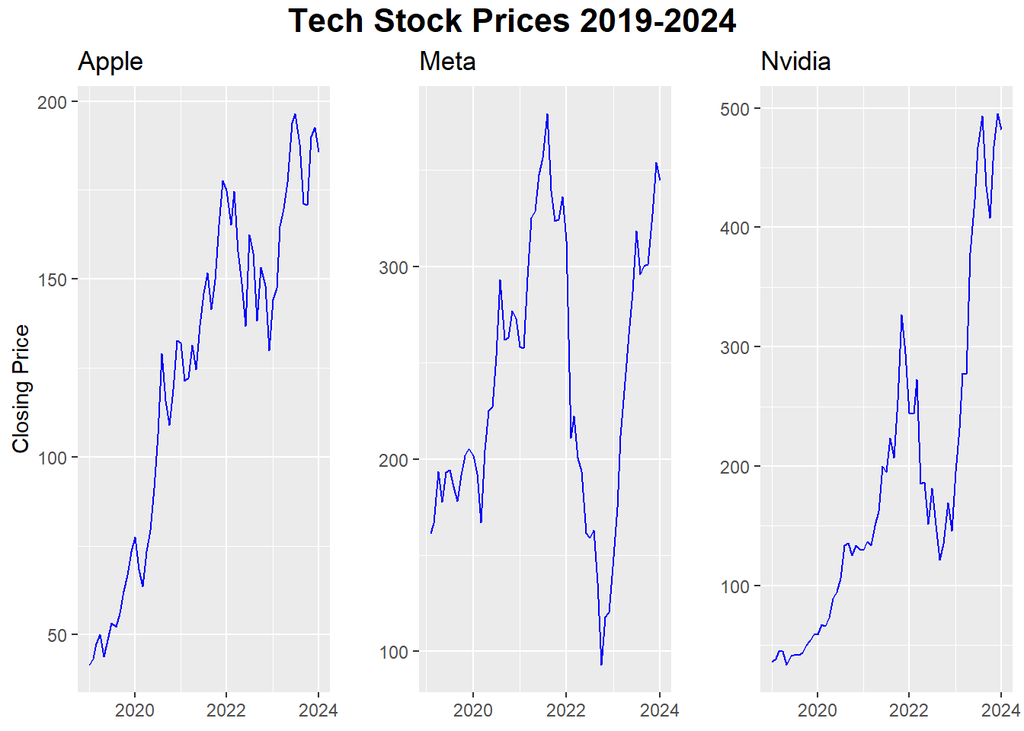

```r
df_list <- list(apple, meta, nvidia)
names_list <- list("Apple", "Meta", "Nvidia")
industry <- "Tech"

invisible(create_industry_graphs(df_list, names_list, industry, "Line_Graph"))
```

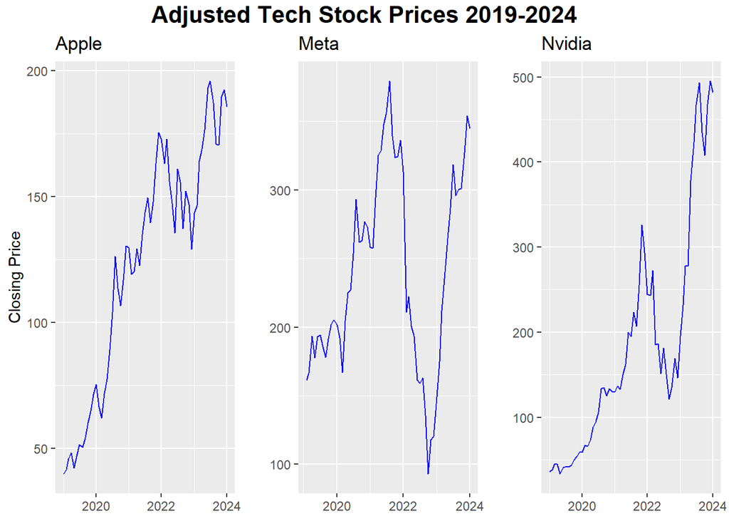

```r
df_list <- list(apple, meta, nvidia)
names_list <- list("Apple", "Meta", "Nvidia")
industry <- "Tech"

invisible(
  create_industry_graphs(
    df_list, names_list, industry, "Line_Graph", adjusted = TRUE
  )
)
```

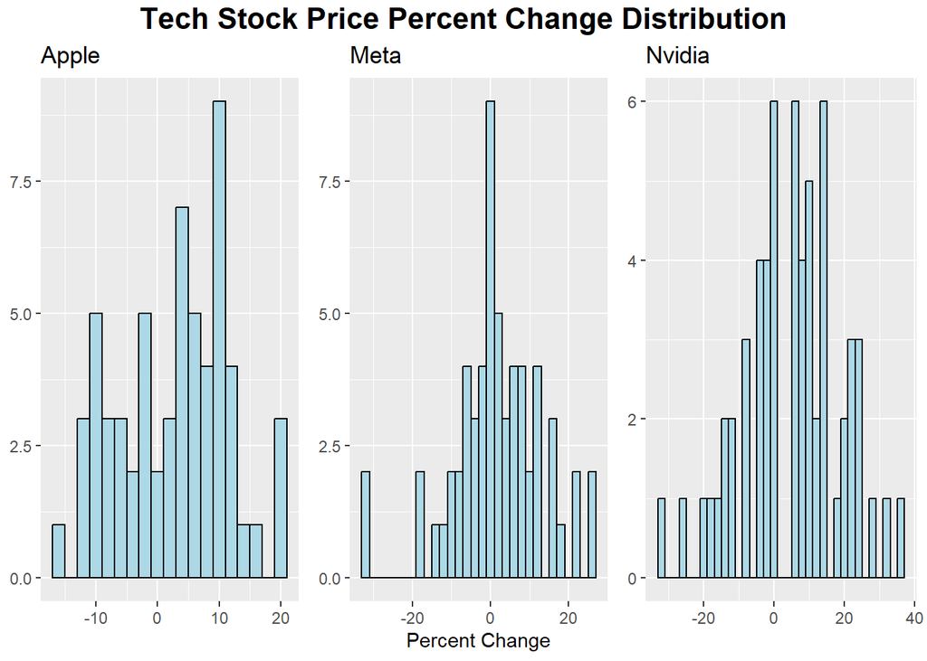

```r
df_list <- list(appl_df, meta_df, nvda_df)
names_list <- list("Apple", "Meta", "Nvidia")
industry <- "Tech"

invisible(
  create_industry_graphs(
    df_list, names_list, industry, "Histogram"
  )
)
```

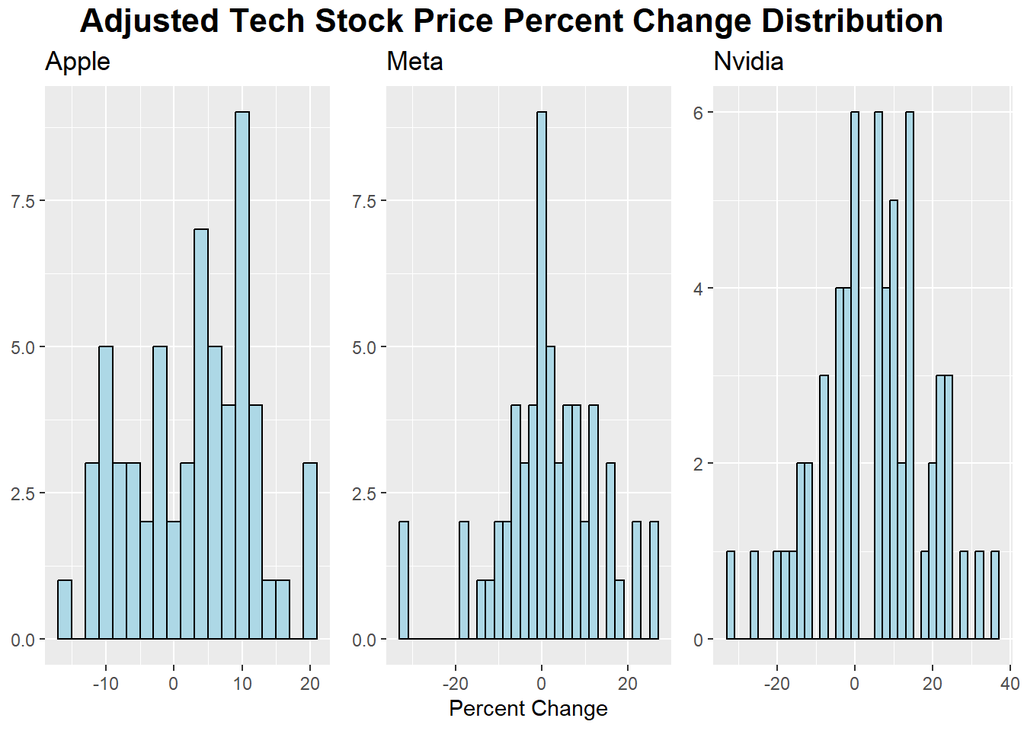

```r
df_list <- list(appl_df, meta_df, nvda_df)
names_list <- list("Apple", "Meta", "Nvidia")
industry <- "Tech"

invisible(
  create_industry_graphs(
    df_list, names_list, industry, "Histogram", adjusted = TRUE
  )
)
```

### Banking Stocks

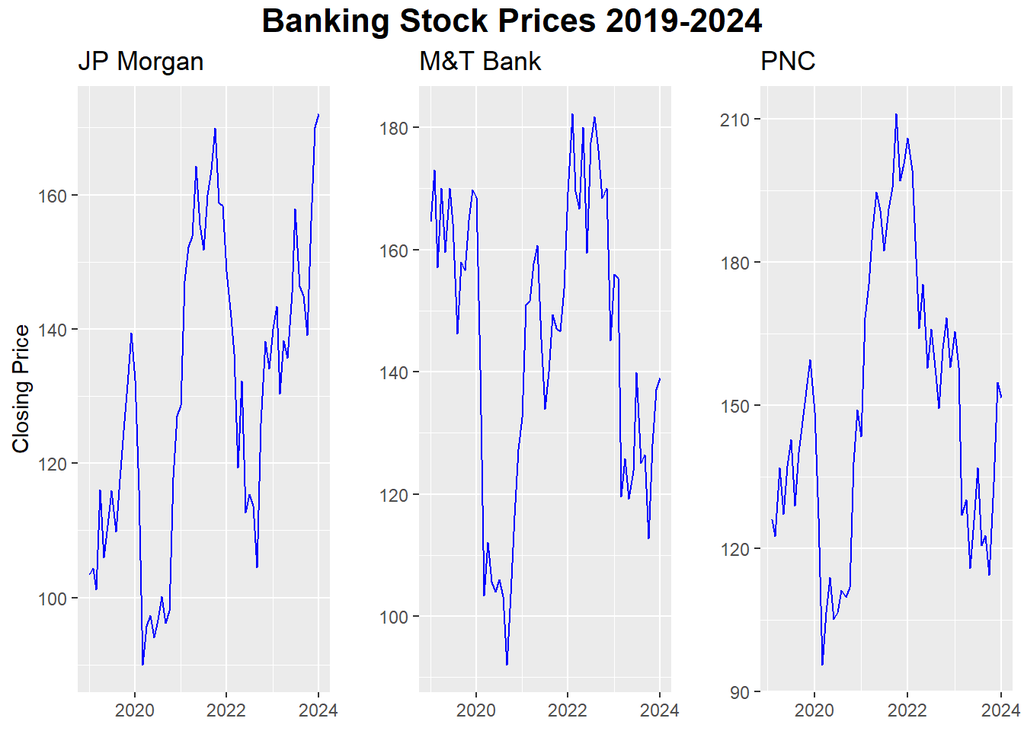

```r
df_list <- list(jpmorg, mandt, pnc)
names_list <- list("JP Morgan", "M&T Bank", "PNC")
industry <- "Banking"

invisible(
  create_industry_graphs(
    df_list, names_list, industry, "Line_Graph"
  )
)
```

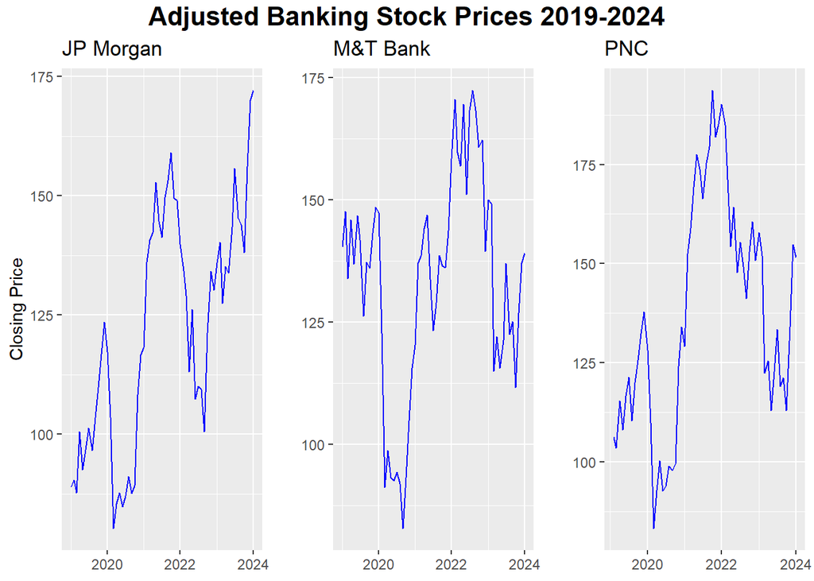

```r
df_list <- list(jpmorg, mandt, pnc)
names_list <- list("JP Morgan", "M&T Bank", "PNC")
industry <- "Banking"

invisible(
  create_industry_graphs(
    df_list, names_list, industry, "Line_Graph", adjusted = TRUE
  )
)
```

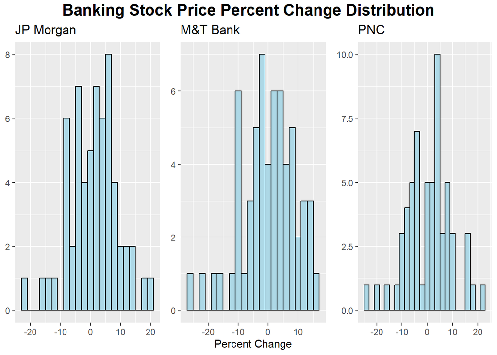

```r
df_list <- list(jpm_df, mtb_df, pnc_df)
names_list <- list("JP Morgan", "M&T Bank", "PNC")
industry <- "Banking"

invisible(
  create_industry_graphs(
    df_list, names_list, industry, "Histogram"
  )
)
```

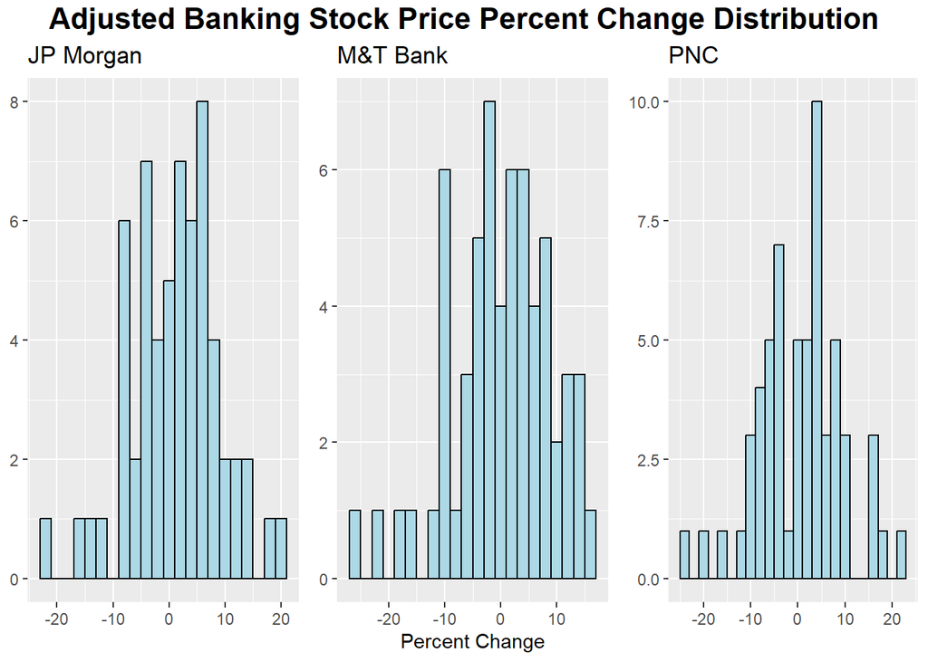

```r
df_list <- list(jpm_df, mtb_df, pnc_df)
names_list <- list("JP Morgan", "M&T Bank", "PNC")
industry <- "Banking"

invisible(
  create_industry_graphs(
    df_list, names_list, industry, "Histogram", adjusted = TRUE
  )
)
```

### Pharmaceutical Stocks

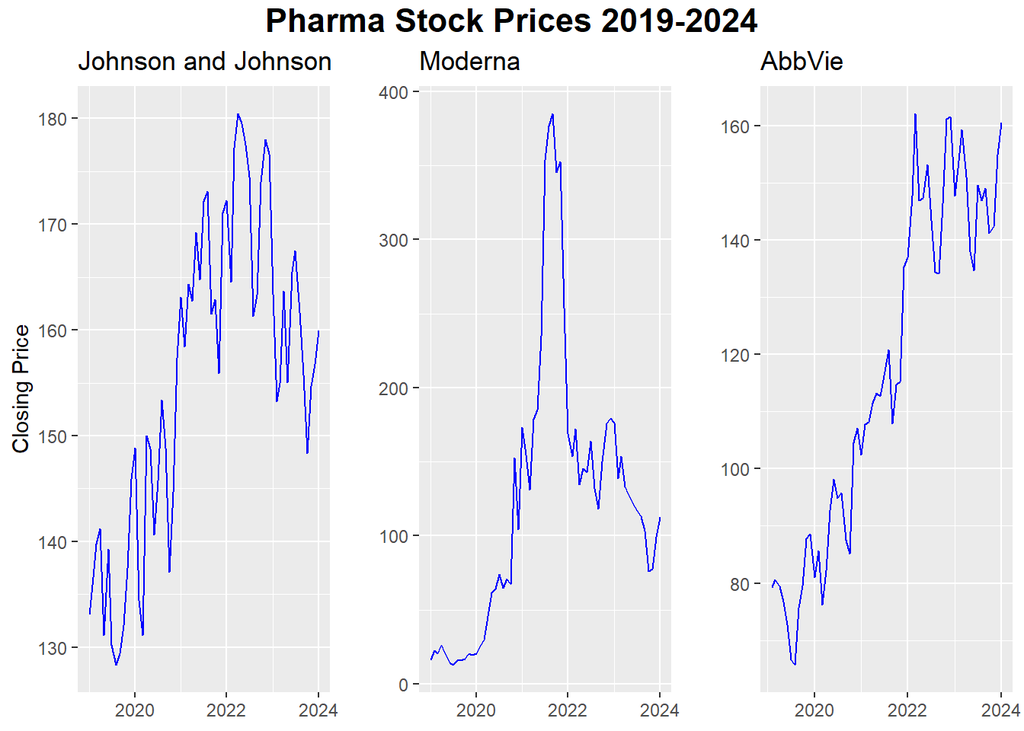

```r
df_list <- list(jnj, moderna, abbvie)
names_list <- list("Johnson and Johnson", "Moderna", "AbbVie")
industry <- "Pharma"

invisible(
  create_industry_graphs(
    df_list, names_list, industry, "Line_Graph"
  )
)
```

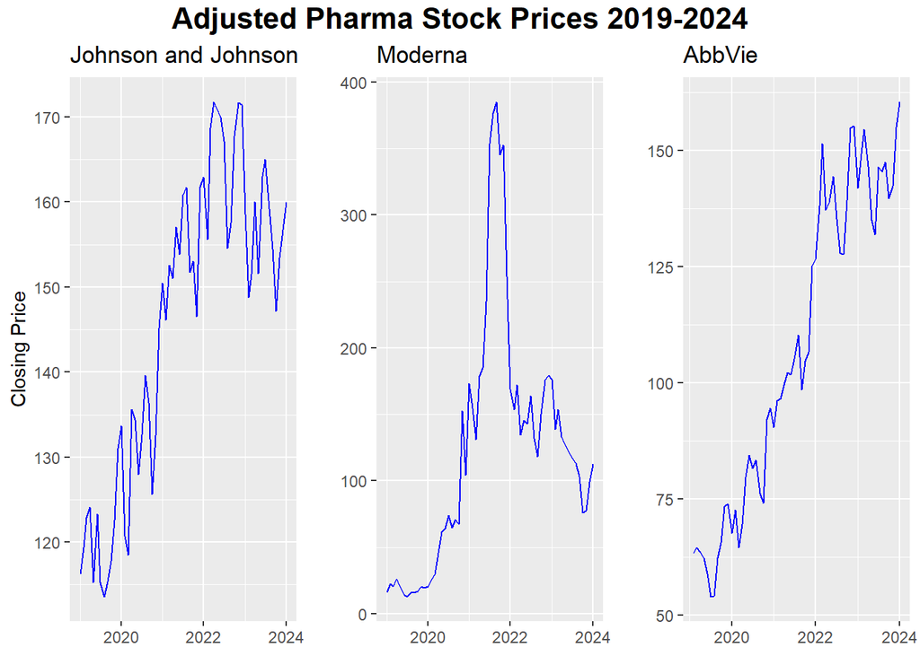

```r
df_list <- list(jnj, moderna, abbvie)
names_list <- list("Johnson and Johnson", "Moderna", "AbbVie")
industry <- "Pharma"

invisible(
  create_industry_graphs(
    df_list, names_list, industry, "Line_Graph", adjusted = TRUE
  )
)
```

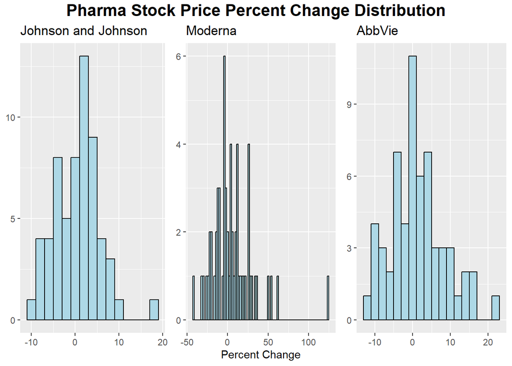

```r
df_list <- list(jnj_df, mrna_df, abbv_df)
names_list <- list("Johnson and Johnson", "Moderna", "AbbVie")
industry <- "Pharma"

invisible(
  create_industry_graphs(
    df_list, names_list, industry, "Histogram"
  )
)
```

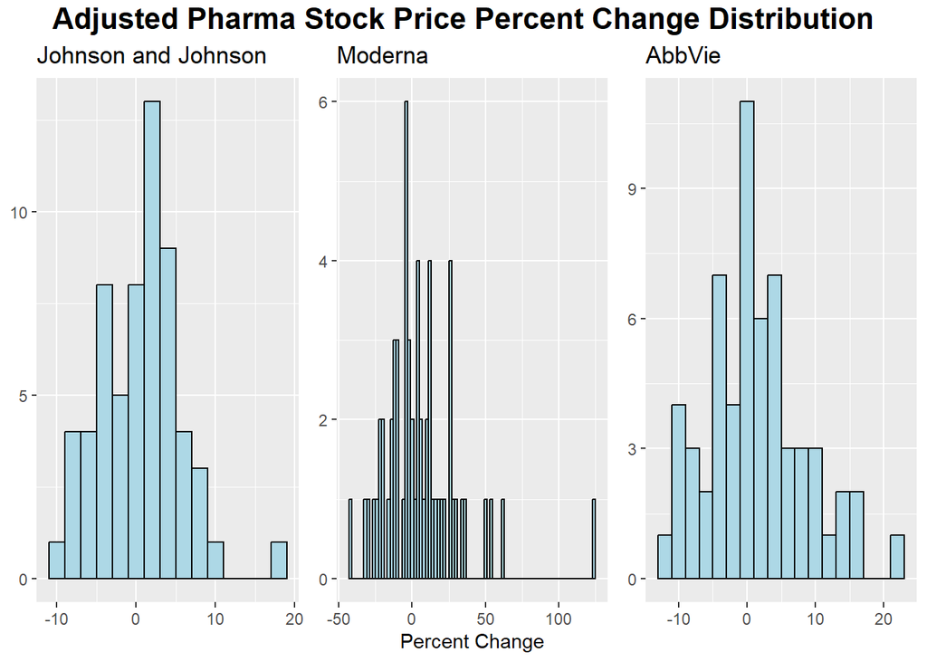

```r
df_list <- list(jnj_df, mrna_df, abbv_df)
names_list <- list("Johnson and Johnson", "Moderna", "AbbVie")
industry <- "Pharma"

invisible(
  create_industry_graphs(
    df_list, names_list, industry, "Histogram", adjusted = TRUE
  )
)
```

### Retail Stocks

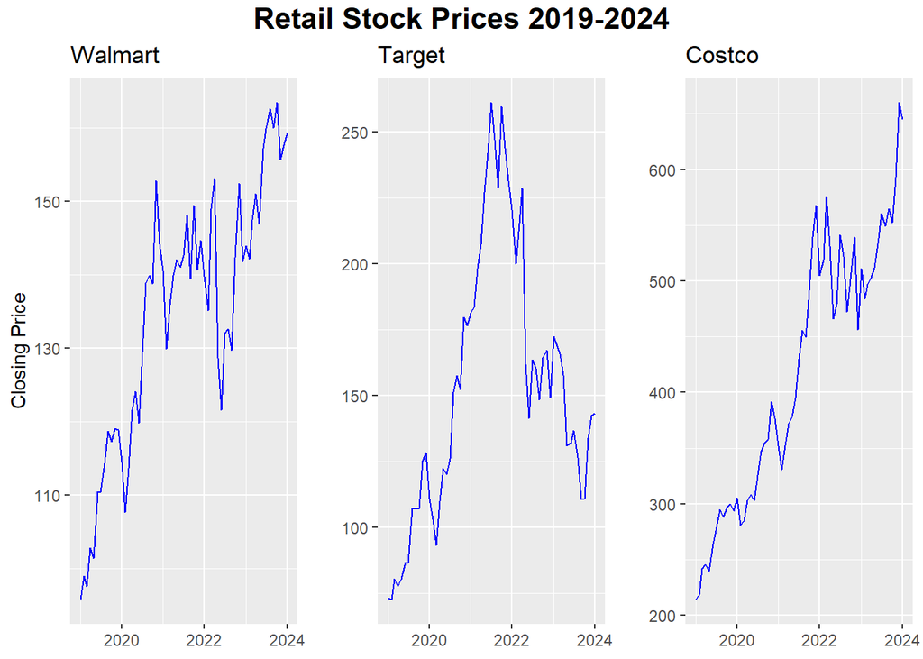

```r
df_list <- list(wmt, target, costco)
names_list <- list("Walmart", "Target", "Costco")
industry <- "Retail"

invisible(
  create_industry_graphs(
    df_list, names_list, industry, "Line_Graph"
  )
)
```

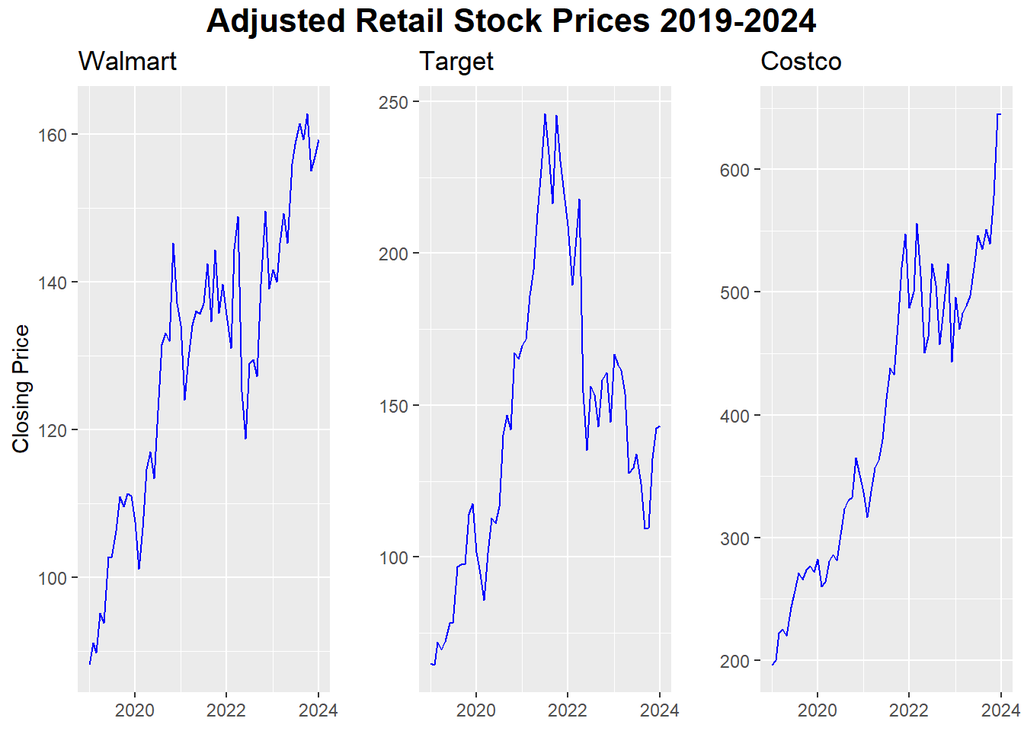

```r
df_list <- list(wmt, target, costco)
names_list <- list("Walmart", "Target", "Costco")
industry <- "Retail"

invisible(
  create_industry_graphs(
    df_list, names_list, industry, "Line_Graph", adjusted = TRUE
  )
)
```

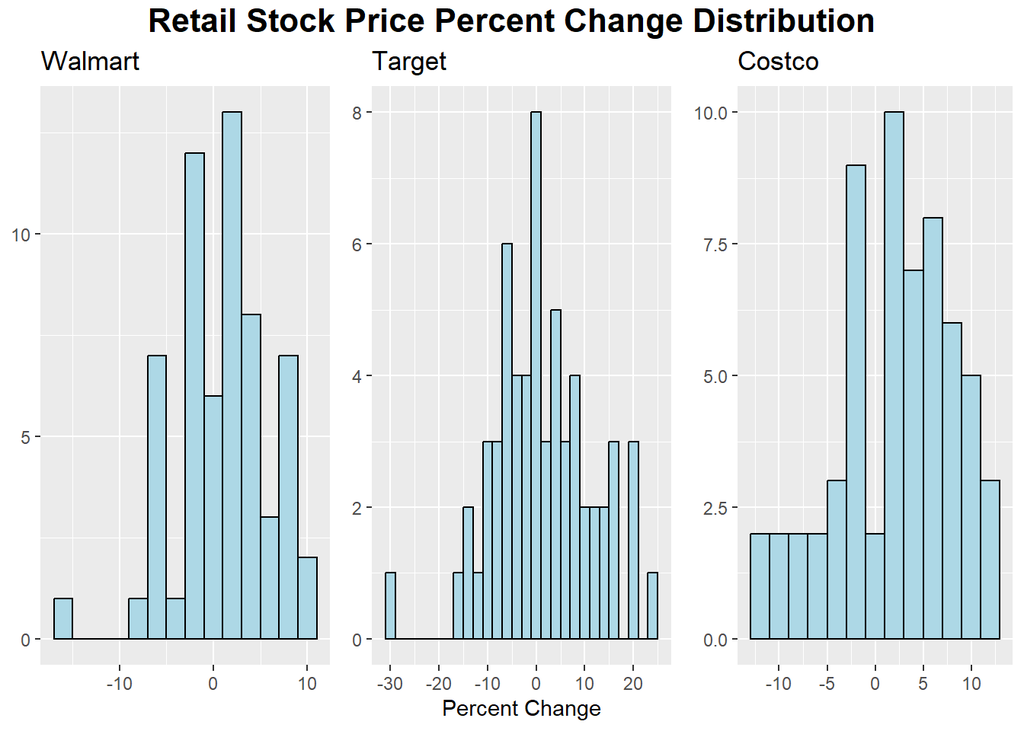

```r
df_list <- list(wmt_df, tgt_df, cost_df)
names_list <- list("Walmart", "Target", "Costco")
industry <- "Retail"

invisible(
  create_industry_graphs(
    df_list, names_list, industry, "Histogram"
  )
)
```

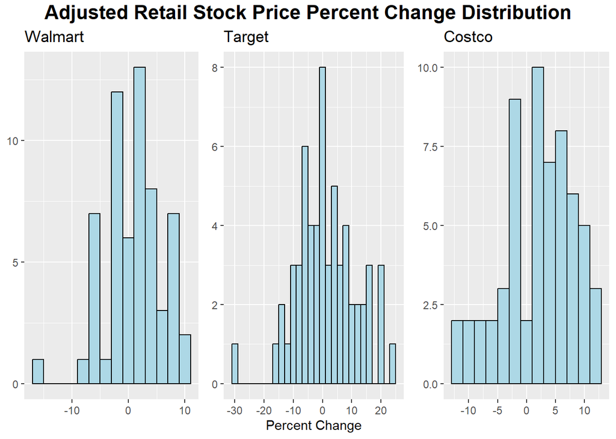

```r
df_list <- list(wmt_df, tgt_df, cost_df)
names_list <- list("Walmart", "Target", "Costco")
industry <- "Retail"

invisible(
  create_industry_graphs(
    df_list, names_list, industry, "Histogram", adjusted = TRUE
  )
)
```

## Overall Stock Price Changes:

[figure not shown]

```r
create_single_stock_histogram(
  combined_df,
  "Overall Monthly Percent Change Distribution",
  "1 Month Percent Change",
  FALSE
)
```

[figure not shown]

```r
create_single_stock_histogram(
  combined_df,
  "Overall Monthly Adjusted Percent Change Distribution",
  "1 Month Adjusted Percent Change",
  TRUE
)
```

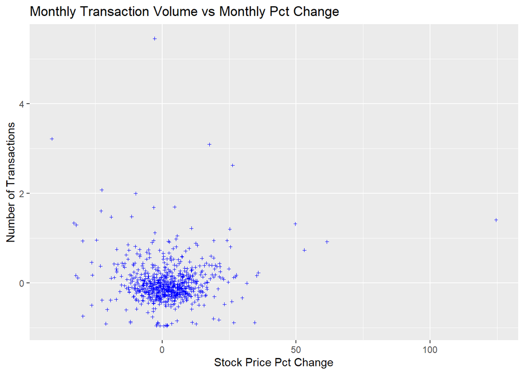

```r
ggplot(combined_df, aes(x = Pct_Change, y = Volume)) +
  geom_point(shape = 3, size = .75, color = "blue") +
  labs(title = "Monthly Transaction Volume vs Monthly Pct Change",
       y = "Number of Transactions",
       x = "Stock Price Pct Change")
```

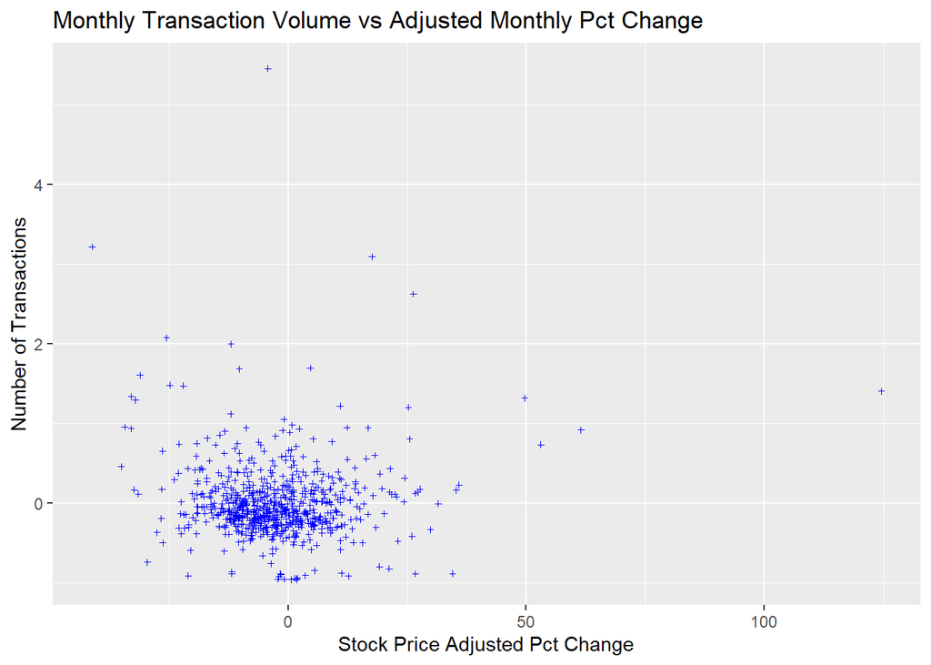

```r
ggplot(combined_df, aes(x = Adj_Pct_Change, y = Volume)) +
  geom_point(shape = 3, size = .75, color = "blue") +
  labs(title = "Monthly Transaction Volume vs Adjusted Monthly Pct Change",
       y = "Number of Transactions",
       x = "Stock Price Adjusted Pct Change")
```

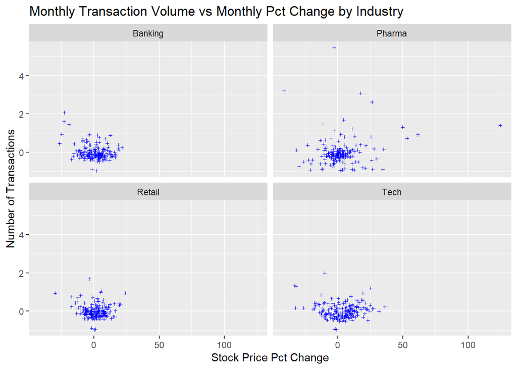

```r
ggplot(combined_df, aes(x = Pct_Change, y = Volume)) +
  geom_point(shape = 3, size = .75, color = "blue") +
  facet_wrap(~Industry) +
  labs(title = "Monthly Transaction Volume vs Monthly Pct Change by Industry",
       y = "Number of Transactions",
       x = "Stock Price Pct Change")
```

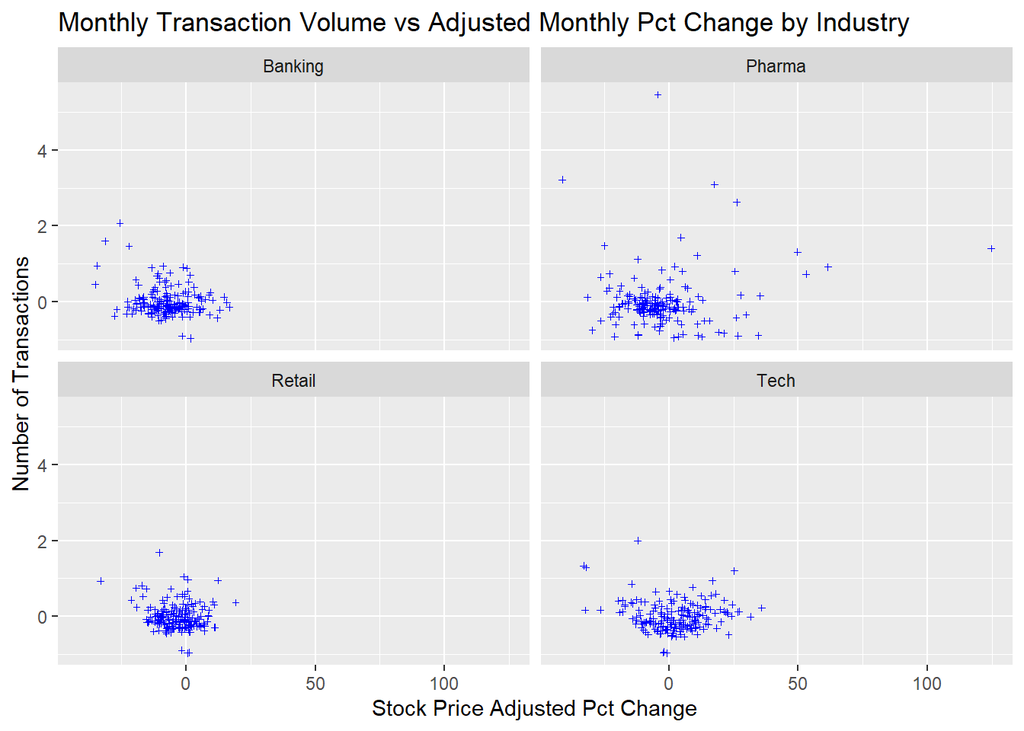

```r
title <- "Monthly Transaction Volume vs Adjusted Monthly Pct Change by Industry"

ggplot(combined_df, aes(x = Adj_Pct_Change, y = Volume)) +
  geom_point(shape = 3, size = .75, color = "blue") +
  facet_wrap(~Industry) +
  labs(
    title = title,
    y = "Number of Transactions",
    x = "Stock Price Adjusted Pct Change"
  )
```

# Data Transformation:

I am now going to create dataframes where each line represents an 8 month period of changes for every line that I can in these dateframes. I will save this as a csv to be used in the actual training dataframe

```r
full_learning_df_8_months <- make_full_learning_df(stock_df_list, 8)
write.csv(
  full_learning_df_8_months,
  file = "PriceChangeByPrevious8Months_Training.csv",
  row.names = FALSE
)
```

6 Month DF:

```r
full_learning_df_6_months <- make_full_learning_df(stock_df_list, 6)
write.csv(
  full_learning_df_6_months,
  file = "PriceChangeByPrevious6Months_Training.csv",
  row.names = FALSE
)
```

12 Month DF:

```r
full_learning_df_12_months <- make_full_learning_df(stock_df_list, 12)
write.csv(
  full_learning_df_12_months,
  file = "PriceChangeByPrevious12Months_Training.csv",
  row.names = FALSE
)
```

4 Month DF:

```r
full_learning_df_4_months <- make_full_learning_df(stock_df_list, 4)
write.csv(
  full_learning_df_4_months,
  file = "PriceChangeByPrevious4Months_Training.csv",
  row.names = FALSE
)
```

10 Month DF:

```r
full_learning_df_10_months <- make_full_learning_df(stock_df_list, 10)
write.csv(
  full_learning_df_10_months,
  file = "PriceChangeByPrevious10Months_Training.csv",
  row.names = FALSE
)
```